# BAIT 509: Business Applications of Machine Learning

## Lecture 2 - Fundamentals of learning, train/test error

Tomas Beuzen, 8th January 2020

# Lecture outline

- 0. Recap (5 mins)
- 1. Lecture learning objectives
- 2. Train/Test error (30 mins)
- 3. ML error, and the "fundamental trade-off" (20 mins)
- --- Break --- (10 mins)
- 4. Train/Validation/Test error and the Golden Rule (10 mins)
- 5. Class Exercise: (25 mins)
- 6. What we've learned today (5 mins)
- 7. Summary questions to ponder

# 0. Recap (5 mins)

- What is machine learning (supervised/unsupervised, classification/regression)
- Machine learning terminology (observations, features, response)
- What is the decision tree algorithm and how does it work
- The scikit-learn library
- Parameters and hyperparameters
- We learned that we can develop and use a machine learning model in just a few lines of code!

```python
import pandas as pd
import numpy as np
from sklearn.tree import DecisionTreeClassifier
df = pd.read_csv('data/cities_USA.csv',
                 index_col=0)  # load data
X = df.drop(columns='vote')  # the features
y = df[['vote']]  # the response
model = DecisionTreeClassifier(max_depth=3)  # initiate model framework
model.fit(X, y)  # fit the model
yp = model.predict(np.atleast_2d([-86, 39]))  # predict something
print(f"At lon = {-86} and lat = {39}, the model predicts: {yp[0]}")
```

```
At lon = -86 and lat = 39, the model predicts: blue
```

Some key questions...

1. How do we choose a value of `max_depth` (or other hyperparameters)?
2. Why not just use large `max_depth` for every supervised learning problem and get super high accuracy?
3. Is model performance on the training data a good indication of how it will perform on new data?

# 1. Lecture learning objectives

- Identify the difference between training error and testing error
- Describe the concept of overfitting and the fundamental tradeoff
- Be able to split a dataset into train and test sets using the `train_test_split()` function
- Describe the golden rule and why it's important

# 2. Train/Test error (30 mins)

- We are going to explore the concept of error in ML models
- Last lecture we briefly touched on model accuracy/error
- Let's briefly revise the concept
- First, let's load in the required packages for this lecture notebook

```python
import numpy as np
import altair as alt
import sys
sys.path.append('code/')
from model_plotting import plot_model
```

- now let's load the cities data (from last lecture) again

```python
df = pd.read_csv('data/cities_USA.csv', index_col=0)
X = df.drop(columns=['vote'])
y = df[['vote']]
```

```python
X
```

|  | lon | lat |
| --- | --- | --- |
| 1 | -80.162475 | 25.692104 |
| 2 | -80.214360 | 25.944083 |
| 3 | -80.094133 | 26.234314 |
| 4 | -80.248086 | 26.291902 |
| 5 | -81.789963 | 26.348035 |
| ... | ... | ... |
| 396 | -97.460476 | 48.225094 |
| 397 | -96.551116 | 48.591592 |
| 398 | -166.519855 | 53.887114 |
| 399 | -163.733617 | 67.665859 |
| 400 | -145.423115 | 68.077395 |

400 rows × 2 columns

```python
y
```

|  | vote |
| --- | --- |
| 1 | blue |
| 2 | blue |
| 3 | blue |
| 4 | blue |
| 5 | blue |
| ... | ... |
| 396 | red |
| 397 | blue |
| 398 | red |
| 399 | red |
| 400 | red |

400 rows × 1 columns

- here's a plot of the data using altair
- don't worry about this code too much, as you have not learned how to use altair and are not expected to know this

```python
alt.Chart(df).mark_circle(size=100,
                                 opacity=1,
                                 stroke='black',
                                 strokeWidth=1
).encode(
    x=alt.X('lon', title='lon', scale=alt.Scale(domain=[-170, -60])),
    y=alt.Y('lat', title='lat', scale=alt.Scale(domain=[20, 70])),
    color=alt.Color('vote')
).properties(
    width=500,
    height=400
).configure_axis(
    labelFontSize=20,
    titleFontSize=20
).configure_legend(
    titleFontSize=20,
    labelFontSize=20
).interactive()
```

[interactive chart not shown]

## 2.1 Training Error

### max_depth=1

- Let's first create a decision tree classifier with `max_depth=1`
- Recall that to create a model:
  - we first make an instance of the model class
  - we then `.fit()` the model with some data

```python
model = DecisionTreeClassifier(max_depth=1)
model.fit(X, y)
```

```
DecisionTreeClassifier(class_weight=None, criterion='gini', max_depth=1,
                       max_features=None, max_leaf_nodes=None,
                       min_impurity_decrease=0.0, min_impurity_split=None,
                       min_samples_leaf=1, min_samples_split=2,
                       min_weight_fraction_leaf=0.0, presort=False,
                       random_state=None, splitter='best')
```

- We can plot our model to visualise how it is classifying our data

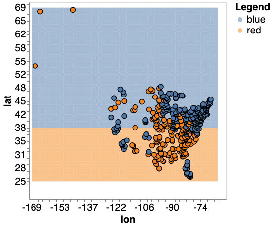

```python
plot_model(X, y, model)
```

- For the case of `max_depth=1` we see that we have smoothed over much of the scatter in our data
- We have a very simple model!
- Recall that we can calculate the error of our model using the `.score()` method
- Previously we talked about accuracy, but typically we work in terms of error (1 - accuracy)

```python
print(f"Error rate: {1 - model.score(X, y):.2f}")
```

```
Error rate: 0.25
```

- We get an error of 0.25
- Can we do better?

### max_depth=None

- Let's specify an unlimited `max_depth`
- I'll also now start chaining `.fit()` on a single line for succinctness

```python
model = DecisionTreeClassifier(max_depth=None).fit(X, y)
```

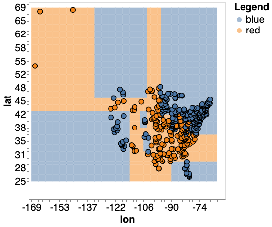

```python
plot_model(X, y, model)
```

- We can see that with this model we are perfectly fitting every observation
- As a result, we except to have a 0 error rate...

```python
print(f"Error rate: {1 - model.score(X, y):.2f}")
```

```
Error rate: 0.00
```

### How does error rate change vs. max_depth?

- Below is a plot of error versus max_depth
- For our decision tree model, we see that error decreases as we increase `max_depth`
- This is not unexpected, as we create a more complex tree (higher max_depth) we can fit all the peculiarities of our data to eventually get 0 error
- We will refer to this as "training error"

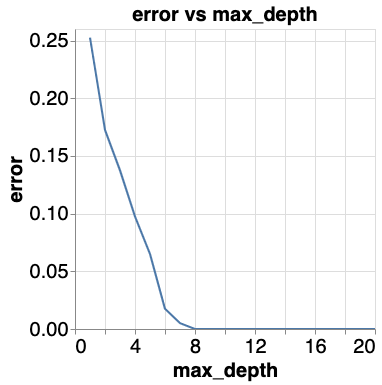

## 2.2 Testing Error

#### Why not just use very large/unlimited `max_depth` for every supervised learning problem and get super high accuracy?

- Well, the goal of supervised learning is to predict unseen/new data...
- We can get 0 error on the training data using `max_depth=None`
- We perfectly classify every data point used to make the model

#### BUT, we want to know how our model performs on data not used in training!

- To do this, we usually split our dataset into parts
- We can use one part for "training" and one part for "testing"

```python
X.shape
```

```
(400, 2)
```

- We see that our dataset contains 400 observations
- Let's use the first half of the data to train our model, and the second half to test it

```python
# Use the first half as training data
X_train = X.iloc[:200]
y_train = y.iloc[:200]
# Use the second half as testing data
X_test = X.iloc[200:]
y_test = y.iloc[200:]
```

```python
model = DecisionTreeClassifier(max_depth=None).fit(X_train, y_train)
```

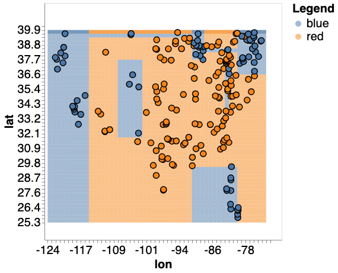

```python
plot_model(X_train, y_train, model)
```

- Let's find our training error (error on the data used to train the model)
- As expected it is 0

```python
print(f"Training error: {1 - model.score(X_train, y_train):.2f}")
```

```
Training error: 0.00
```

- But what about the test data?
- Let's plot the data (scatter points) along with our model (shaded region)
- We definitely see some misclassified points here!

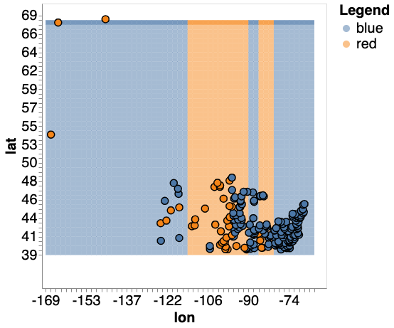

```python
plot_model(X_test, y_test, model)
```

- We can already see that we aren't getting 0 error here
- Let's find out what the error actually is
- We will call this **testing error**

```python
print(f"Testing error: {1 - model.score(X_test, y_test):.2f}")
```

```
Testing error: 0.30
```

- What is going on here???
- We have terrible accuracy on the test set!
- Maybe we didn't split our data very well...
- Maybe the first half of the data has some order to it that doesn't well represent the whole dataset...

```python
X
```

|  | lon | lat |
| --- | --- | --- |
| 1 | -80.162475 | 25.692104 |
| 2 | -80.214360 | 25.944083 |
| 3 | -80.094133 | 26.234314 |
| 4 | -80.248086 | 26.291902 |
| 5 | -81.789963 | 26.348035 |
| ... | ... | ... |
| 396 | -97.460476 | 48.225094 |
| 397 | -96.551116 | 48.591592 |
| 398 | -166.519855 | 53.887114 |
| 399 | -163.733617 | 67.665859 |
| 400 | -145.423115 | 68.077395 |

400 rows × 2 columns

- We do indeed see that our data is ordered by latitude!
- This means that we are training only on lower latitudes (the first 200 observations) and testing on higher latitudes (the last 200 observations)
- No wonder our model is not doing so well...
- Luckily, there's a solution
- The sklearn function `train_test_split()` is the most common function used to split data into train/test sets
- it shuffles the data first, then splits it
- It can be imported as follows

```python
from sklearn.model_selection import train_test_split
```

```python
# shuffles and then splits
X_train, X_test, y_train, y_test = train_test_split(X, y, test_size=0.5)
```

- Let's remake our model on this new training data and print the training error and testing error

```python
model = DecisionTreeClassifier(max_depth=None).fit(X_train, y_train)
print(f"Training error: {1 - model.score(X_train, y_train):.2f}")
print(f"Testing error: {1 - model.score(X_test, y_test):.2f}")
```

```
Training error: 0.00
Testing error: 0.11
```

- Ah, we are doing much better than before!
- But still the errors are not the same
- The testing error seems to be different to the training error
- The punch line: ### the error rate on our training data may NOT be a good indicator of error rate on new data

# -------- Break (10 mins) --------

# 3. ML error, and the "fundamental trade-off" (20 mins)

## Error

- Error is composed of two quantities: **irreducible error** and **reducible error**

### Irreducible error

- Recall that we are trying to model `Y` which is a random variable, i.e., $Y=f(X)+\epsilon$
- We use ML to help us determine the function $f(X)$
- $\epsilon$ is the random error term
- This is measurement error that cannot be reduced no matter how good our model is
- For example, say we are interested in modelling the height of human beings
- Let's say this quantity is normally distributed with mean=165, sd=30:

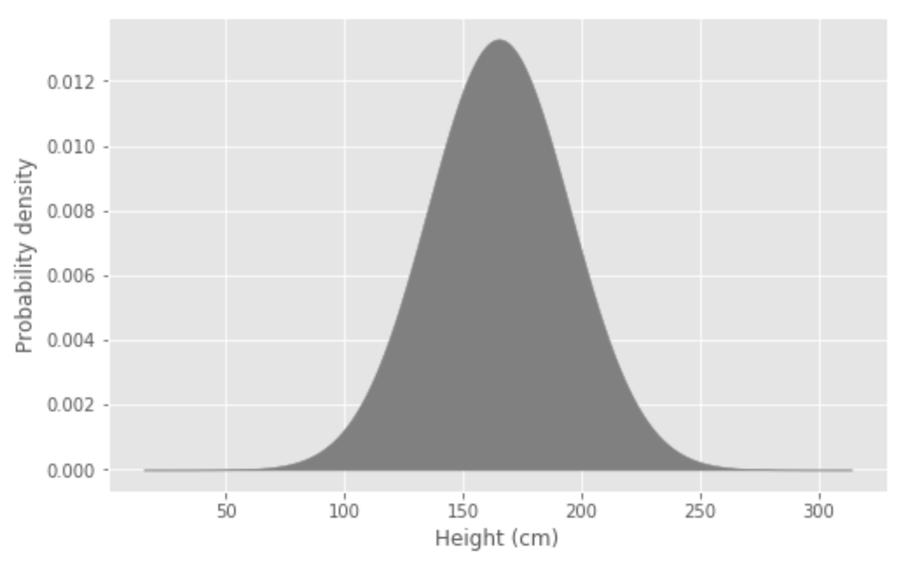

- If we pick a random person in the world, we are uncertain about what their height is (according to the above distribution)
- But the whole point of prediction is that we can use features (`X`) to become more certain!
- For example, if we know the person's gender is female we can narrow our distribution to the blue distribution (because females are on average shorter than males):

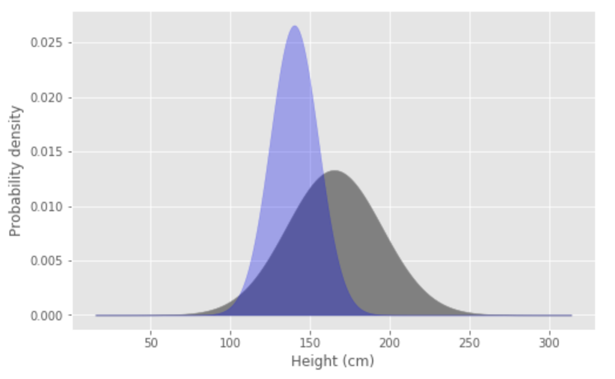

- If we know a person's sex is female and their weight is 65kg, we can narrow our distribution further to the red distribution (because weight and height are generally correlated):

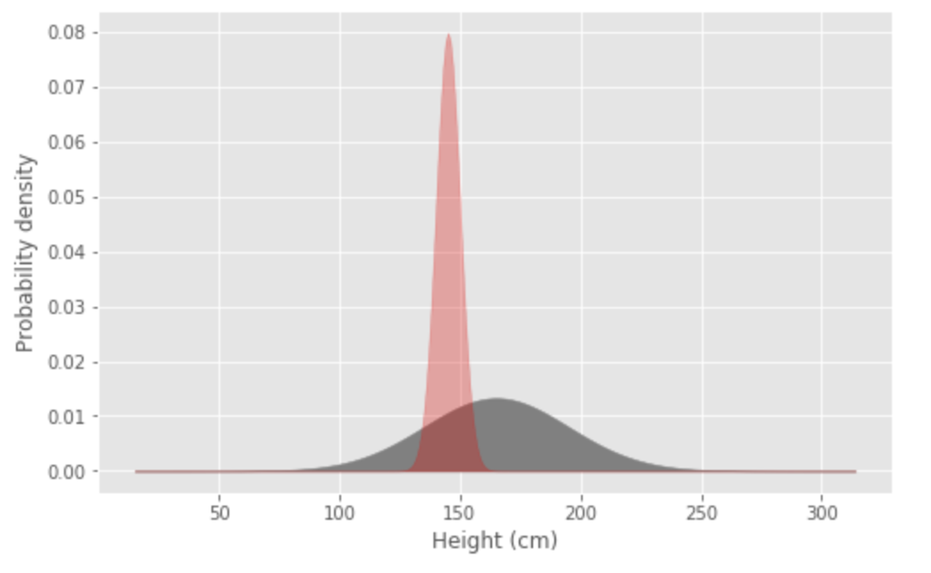

- But the point here is that we can never be exactly certain of `Y` no matter what, there is always uncertainty!
- (these are random variables after all, if they weren't random, we wouldn't need machine learning to predict them!)
- We simply cannot account for all the things that influence a person's height
- So what’s one to do?
- Well we try to make the most certain predictions we can (to minimise uncertainty)

### Reducible error

- As the name suggests, this is the error that we can reduce
- It is related to the model we are using to make predictions
- (this is in contrast to irreducible error which is related to the data)
- We decompose reducible error into **bias** and **variance**
- Bias = difference between model predictions and the true value (think of it as the error rate we've been calculating)
- Variance = variability of model predictions (think of it as the difference in error rate between train and test sets)
- So how does this relate to our train vs test error problem?

## Underfitting/Overfitting

- **Underfitting** = when a model is too simple and not well fit to the patterns in the data (high bias, low variance)
  - e.g., A decision tree with `max_depth=1`
- **Overfitting** = when a model fits too closely to the peculiarities in the training data (low bias, high variance)
  - e.g., A decision tree with `max_depth=None`
- There is usually (always?) a tradeoff between bias and variance
- It’s referred to as the "fundamental trade-off"/"bias-variance tradeoff"
- Here's the typical picture:
  - Bias initially reduces as models become more complex
  - However as models become even more complex, variance increases
  - The best models have low bias and low variance

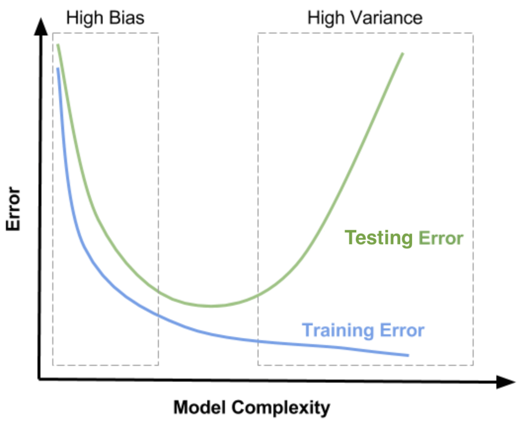

[Source: dziganto.github.io](https://dziganto.github.io/cross-validation/data%20science/machine%20learning/model%20tuning/python/Model-Tuning-with-Validation-and-Cross-Validation/)

- How about for our data?
- The test error of decision tree models typically does not increase over time
- Why?

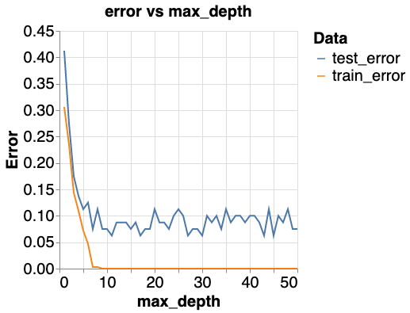

## Finding the "optimal model"

- So to find the optimal model, we split our data into train and test sets, find the error for different `max_depth` values (or any other hyperparameters) and pick the best one?
- EASY!
- Using the above plot for reference, we see that picking a max_depth > 10 will generally give us the lowest error, great!
- But is there something wrong with this approach to selecting hyperparameter values?